# 02 Exploratory data analysis

# Exploratory data analysis

> I know of no person or group that is taking nearly adequate advantage of the graphical potentialities of the computer.The greatest value of a picture is when it forces us to notice what we never expected to see. John Tukey [-@Tukey1977exploratory, p. vi]

## Why doing exploratory data analysis?

Discrete choice modelling covers a family of techniques useful to infer decision-making processes in many disciplines, including economics, transportation engineering and planning, geography, among many others. Discrete choice analysis is well represented in a variety of journals, including specialized outlets such as the Journal of Choice Modelling, and is a preferred tool in many applications due to the rich behavioral interpretation of the models.

Thousands of applications of discrete choice analysis are found in the literature, which have greatly contributed to our understanding of processes ranging from mode choices, altruistic behavior, etc. Modellers know well that estimating and interpreting a discrete choice model are only two aspects in a more extended data analysis process, that ranges from data collection to presentation of results to inform policy. From a data analysis perspective, a key aspect of the process is Exploratory Data Analysis (EDA). EDA is an aspect of modelling that is often taken for granted, and that is not widely reported in the literature, despite playing an important role in the development and use of discrete choice models.

EDA can be used at different stages of the modelling process. Pre-estimation EDA consists in analyzing the data before estimating the model. It is mainly a knowledge discovery technique and allows:

- Exploring the various variables and detecting outliers
- Exploring the relationship between the variables and formulating hypotheses
- Detecting, revealing, describing and representing patterns of association, underlying structures of dependencies

Post-estimation analysis consists in exploratory techniques for communication and is conducted after the model is estimated. It is useful to provide a more intuitive interpretation of the results presented in the model.

For now, we will focus on pre-estimation EDA.

## Learning objectives

In this practice, you will learn about:

1. Different ways to explore the data
2. Bivariate and multivariate visualization techniques.

## Bivariate analysis

Before specifying and estimating a model, it is importante to explore how the variables relate to each other and to formulate hypotheses. Bivariate analysis consists in visualizing the relationship between two variables. The boxplot presented in course 01 is an example of a bivariate vizualisation. We will now build on this example to explore other visualization techniques.

First, always remember to clean the workspace.

```r
rm(list = ls())
```

Let’s now load the packages that will be required to conduct the visualization. If you haven’t previously installed these packages on your work station, make sure to do so now.

```r
library(tidyverse)
library(readr)
library(mlogit)
library(vcd)
library(gplots)
library(ggplot2)
#library(caret)
```

And the dataset:

```r
mc_mode_choice <- read_csv("Commute Mac.csv")
```

About the dataset: The dataset contains data about commute trips to McMaster University.

### Boxplot

Again, before doing any analysis,it is important to inspect the summary statistics of the variables of interest:

```r
mc_mode_choice %>% select(c("choice", "side_den")) %>% summary()
```

```
     choice         side_den
 Min.   :1.000   Min.   : 0.00
 1st Qu.:2.000   1st Qu.:18.19
 Median :2.000   Median :22.63
 Mean   :2.618   Mean   :24.18
 3rd Qu.:3.000   3rd Qu.:35.70
 Max.   :4.000   Max.   :59.41
```

Anything wrong with the data?

Let’s solve this:

```r
mc_mode_choice$choice <- factor(mc_mode_choice$choice, labels = c("Cycle", "Walk", "HSR", "Car"))
mc_mode_choice %>% select(c("choice", "side_den")) %>% summary()
```

```
   choice       side_den
 Cycle: 48   Min.   : 0.00
 Walk :711   1st Qu.:18.19
 HSR  :336   Median :22.63
 Car  :281   Mean   :24.18
             3rd Qu.:35.70
             Max.   :59.41
```

Below is the boxplot presented in the previous course:

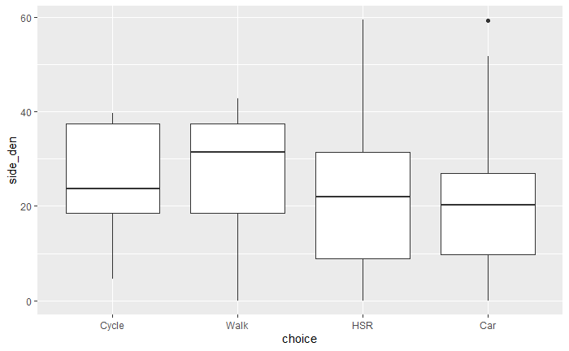

```r
ggplot(data = mc_mode_choice, aes(x = choice, y = side_den)) + geom_boxplot()
```

What can you learn from this figure? What are the variables? How is side_den measured?

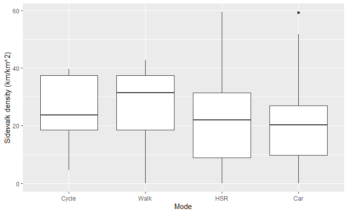

```r
ggplot(data = mc_mode_choice, aes(x = choice, y = side_den)) +
  geom_boxplot() +
  labs(x="Mode", y = "Sidewalk density (km/km^2)")
```

It is important to provide the reader with the basic information, directly in the figure. This way, the reader can directly interpret the results, without having to go back to the definition of the variables for example.

### Violin plot

Another way to plot the interactions between a continuous and a discrete variable is the violon plot. In addition to plotting the quartile values (last code line), the violon plot illustrates the distribution of the values for each category (third code line). Let’ see.

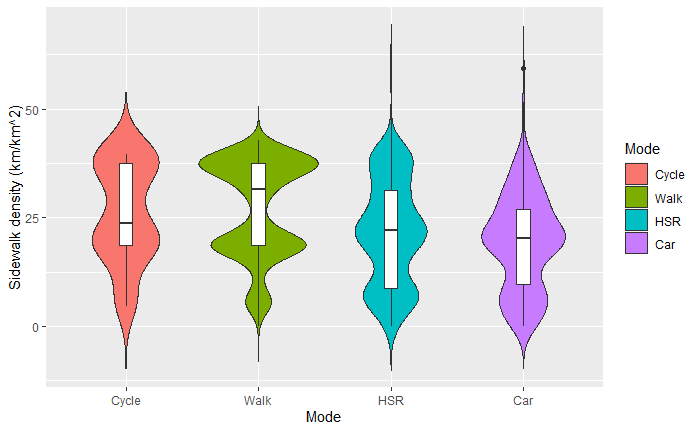

```r
ggplot(mc_mode_choice, aes(x=choice, y=side_den, fill=choice)) +
  labs(x="Mode", y = "Sidewalk density (km/km^2)", fill = "Mode")+
  geom_violin(trim=FALSE) +
  geom_boxplot(width=0.1, fill="white")
```

Comparing the violon plot with the boxplot, we obseve that some pieces of information are not visible in the boxplot. For example, if you look at the Walk mode, what can you observe? What could be the reason for this?

Some techniques allow us to extract more information. Yet, this is not always useful, it always depend on the data you have and on the information that is relevant to the model specification, estimation, results and interpretation.

### Balloon plot

The previous examples explored the relationship between a categorical variable and a continuous variable. Yet, discrete choice modelling often involves several categorical variables.

The first step to exploring two categorical variables is to create a contingency table. This table presents the conditional frequency distribution or the cross-classification of frequencies for a set of two variables. The contingency table, of frequency distributions, can then be explored visually through a diversity of charts and plots. The most common are the following: balloon plots and mosaic plots.

The balloon plot is a direct representation of the conditional frequency, where the size of the circle is proportional to the conditional frequency. Also, the marginal frequency is illsutrated through bars, the size of these bars being proportional to it.

[figure not shown]

```r
tableau=table(mc_mode_choice$choice, mc_mode_choice$owncycle)
balloonplot(as.table(tableau),
            xlab="Mode choice",
            ylab="Bicycle ownership",
            dotsize=3/max(strwidth(19),strheight(19)),
            dotchar=19,
            dotcolor="skyblue",
            text.size=0.65,
            text.color=par("fg"),
            main="Mode choice as a function of gender",
            label=TRUE,
            label.digits=2,
            label.size=0.80,
            label.color=par("fg"),
            scale.method=c("volume","diameter"),
            scale.range=c("absolute","relative"),
            colsrt=par("srt"),
            rowsrt=par("srt"),
            colmar=1,
            rowmar=2,
            show.zeros=FALSE,
            show.margins=TRUE,
            cum.margins=TRUE,
            sorted=TRUE,
            label.lines=TRUE,
            fun=function(x)sum(x,na.rm=T),
            hide.duplicates=TRUE )
```

The size of the circles allow for a quick comparison between the frequency distribution. Looking at the results, it is possible to observe that almost all individuals who cycle do own a bicycle, which is consistent with our expectations. In contrast,more than half the individuals who walk do not own a bicycle, whereas the proportions are similar for public transport and car users. In addition, looking at the grey rectangles, we can see that a bit less than half the respondents own a bicycle and a greater proportion of respodents walk, in comparison to other modes.

Note that the statistical significance of the associations can be tested through a chi-square test.

### Mosaic plot

The mosaic plots builds on the two-way contingency table and displays the conditional frequencies in the form of stacked bar charts, where the area is proportional to the observed frequency. The width of the bars reflects the relative frequency of one variable and the height reflects the conditional frequency of the second variable, as a function of the first one (or vice-versa).

The mosaic function presented here is part of the vcd pacckage. Looking again at the relationship between bicycle ownership and mode choice, we obtain the following figure.

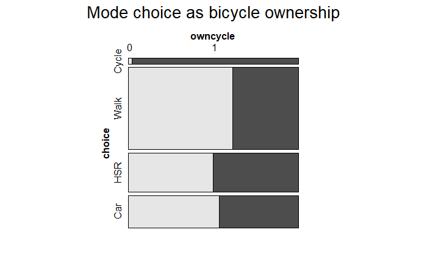

```r
mosaic(owncycle ~ choice, mc_mode_choice, main="Mode choice as bicycle ownership")
```

In comparison with the balloon plot, the mosaic plot provides a more intuitive representation of the conditional frequency distribution, yet with no numbers. Individuals who walk and do not own a bicycle are the largest group, whereas the one individual who cycles but do not own a bicycle represents the smallest group.

How can the figure above be improved?

It is also possible to illustrate the statistical “significance”/strength of the of the relationships, by calculating and displaying the pearson residuals in the mosaic plot. The residuals are calculated based on a model of equal marginal probabilities

## Multivariate analysis

When conducting discrete choice analysis, modellers are influenced in the joint influence of multiple variables. It is, therefore, relevant to explore the relationship between more than two variables.

## Exercise

### Questions

1. Explore the relationships between the different variables in the dataset. Derive and discuss at least two interesting hypotheses using bivariate EDA?

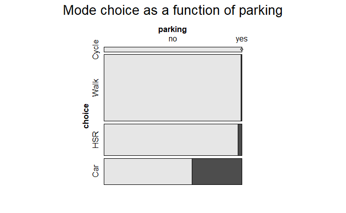

```r
mc_mode_choice$parking = factor(mc_mode_choice$parking, labels=c('no','yes'))

mosaic(parking ~ choice, mc_mode_choice, main="Mode choice as a function of parking")
```